# Análise de dados de gastos dos deputados brasileiros

Isabelly Cavalcante

30 de março de 2017

## 1) Visão geral

Esta atividade faz parte da disciplina de Fundamentos de Pesquisa em Ciência da Computação II da Pós-Graduação em Ciência da Computação na Universidade Federal de Campina Grande. Nosso objetivo aqui é se familiarizar com a ferramenta analisando dados e respondendo a duas perguntas:

1. Em que tipo de despesas os parlamentares gastam mais recursos de sua cota?
2. Que tipos de despesa tem valores que mais variam quando comparamos os deputados?

## 2) Dados

Os dados que são a base da análise descrevem os gastos realizados pelos deputados brasileiros no período de 2015-hoje. Eles foram coletados do site da transparência da camâra dos deputados em http://www2.camara.leg.br/transparencia/cota-para-exercicio-da-atividade-parlamentar/dados-abertos-cota-parlamentar. As explicações sobre cada dado disponível se encontra em http://www2.camara.leg.br/transparencia/cota-para-exercicio-da-atividade-parlamentar/explicacoes-sobre-o-formato-dos-arquivos-xml.

Devido a enorme lista de variáveis existentes segue abaixo uma explicação sobre as variáveis que serão faladas aqui (no contexto da Cota CEAP).

txNomeParlamentar | Nome Parlamentar | Nome adotado pelo Parlamentar ao tomar posse do seu mandato.

sgUF | Sigla da UF | Representa a unidade da federação pela qual o deputado foi eleito e é utilizada para definir o valor da cota a que o deputado tem.

numSubCota | Número da Subcota | Representa o código do Tipo de Despesa referente à despesa realizada pelo deputado e comprovada por meio da emissão de um documento fiscal, a qual é debitada na cota do deputado.

txtDescricao | Descrição da Subcota | O seu conteúdo é a descrição do Tipo de Despesa relativo à despesa em questão.

vlrLiquido | Valor Líquido | Representa o valor líquido do documento fiscal ou do documento que deu causa à despesa e será calculado pela diferença entre o Valor do Documento e o Valor da Glosa. É este valor que será debitado da cota do deputado.

## 3) Atividade

Agora vamos começar a atividade carregando nossas bibliotecas e dados:

```r
library(readr)
library(ggplot2)
library(dplyr)
library(gmodels)

dados_gastos <- read_csv("~/Dados_FPCC2/gastos-cota_atividade_parlamentar.csv")
```

## 3.1) Deputados por estado

Como primeira consulta decidi ver o número de deputados por estado para começar a ter uma noção dos dados.

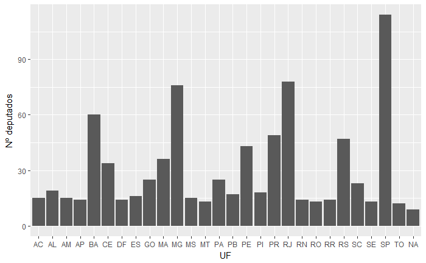

```r
# No comando abaixo eu selecionei apenas os nomes dos deputados e seu estado, agrupei por estado e sumarizei para chamar de somaDepEstado a soma de deputados de um mesmo estado.
dep_Por_Estado = dados_gastos %>%
  select(txNomeParlamentar, sgUF) %>%
  distinct() %>%
  group_by(sgUF) %>%
  summarise(qtd_Dep_Estado = n())
# Já aqui eu fiz o plote desses dados usando um gráfico de barras onde x é o estado e y o número de deputados
ggplot(dep_Por_Estado) +
  geom_bar(stat="identity", mapping = aes(x = sgUF, y = qtd_Dep_Estado)) +
  labs(x='UF', y='Nº deputados')
```

## 3.2) Tipos de despesas existentes

Agora daremos uma olhada nos tipos de despesas existentes nos dados.

```r
# Aqui consultei dos dados apenas os tipos e ids distintos e renomeei os nomes das colunas para Despesa e Id respectivamente
tipos_Despesas = dados_gastos %>%
  select(txtDescricao, numSubCota) %>%
  distinct()
  colnames(tipos_Despesas) = c('Despesa', 'Id')
# Impressão da consulta
tipos_Despesas %>% select(Id, Despesa)
```

| Id | Despesa |
| --- | --- |
| 1 | MANUTENÇÃO DE ESCRITÓRIO DE APOIO À ATIVIDADE PARLAMENTAR |
| 3 | COMBUSTÍVEIS E LUBRIFICANTES. |
| 4 | CONSULTORIAS, PESQUISAS E TRABALHOS TÉCNICOS. |
| 5 | DIVULGAÇÃO DA ATIVIDADE PARLAMENTAR. |
| 8 | SERVIÇO DE SEGURANÇA PRESTADO POR EMPRESA ESPECIALIZADA. |
| 10 | TELEFONIA |
| 11 | SERVIÇOS POSTAIS |
| 120 | LOCAÇÃO OU FRETAMENTO DE VEÍCULOS AUTOMOTORES |
| 999 | Emissão Bilhete Aéreo |
| 9 | PASSAGENS AÉREAS |

[output cut: 8 more lines]

## 3.3) Pergunta 1 - Despesas ordenadas por gastos

Agora que já vimos alguns gráficos extraidos dos dados responderemos a primeira pergunta da atividade. Eu escolhi a variável numSubCota porque ela fica melhor de visualizar no gráfico do que se eu usasse o txtDescricao. Já a variável vlrLiquido foi porque de acordo com as definições das variáveis é este valor que será debitado da cota do deputado.

```
Ignoring unknown parameters: binwidth, bins, pad
```

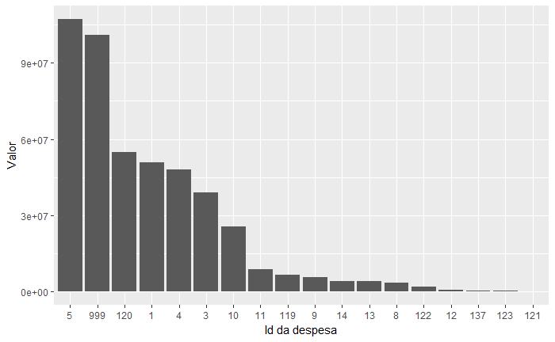

```r
qt_Gastos = dados_gastos %>%
 select(numSubCota, vlrLiquido) %>%
  group_by(numSubCota) %>%
  summarise(vlr_Liquido = sum(vlrLiquido))
ggplot(qt_Gastos) +
  geom_histogram(stat="identity", mapping = aes(x = reorder(numSubCota, -vlr_Liquido), y = vlr_Liquido), bins = 18) +
  labs(x='Id da despesa', y='Valor')
```

Com isso podemos saber os ids das despesas e os seus respectivos gastos. Sabendo o id podemos consultar na tabela de antes para saber os nomes das despesas. Então respondendo a primeira pergunta da atividade, o tipo de despesa que os deputados mais gastam é a despesa com id 5, que quando verificada na tabela acima vemos que é DIVULGAÇÃO DA ATIVIDADE PARLAMENTAR seguido de Emissão Bilhete Aéreo (id 999) e LOCAÇÃO OU FRETAMENTO DE VEÍCULOS AUTOMOTORES (id 120).

## 3.4) Pergunta 2 - Despesas com gastos que mais variam quando comparados os deputados

Essa etapa eu tive um pouco de dificuldade porque mistura três variáveis. Como aconselhado eu diminui o escopo de deputados e de tipo de despesas. O escopo que estarei usando a baixo são os deputados da Paraíba e de Pernambuco, porque são estados onde vivi. E de despesas são DIVULGAÇÃO DA ATIVIDADE PARLAMENTAR(id 5), PASSAGENS AÉREAS(id 9) e MANUTENÇÃO DE ESCRITÓRIO DE APOIO À ATIVIDADE PARLAMENTAR(id 1).

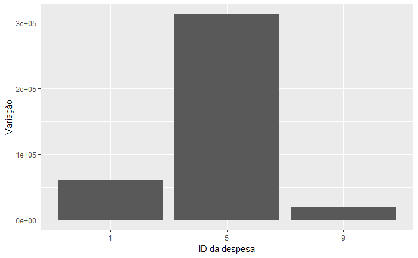

```r
# Primeiro vamos reduzir o escopo dos deputados e dos tipos de despesas
dep_PB_PE = filter(dados_gastos, dados_gastos$sgUF == "PB"  | dados_gastos$sgUF == "PE")
dep_PB_PE2 = filter(dep_PB_PE, dep_PB_PE$numSubCota == 1 | dep_PB_PE$numSubCota == 5 | dep_PB_PE$numSubCota == 9)
# Aqui eu agrupei os nomes dos deputados e os ids das despesas e sumarizei dos valores liquidos pelo desvio
x = dep_PB_PE2 %>%
  select(txNomeParlamentar, numSubCota, vlrLiquido) %>%
  group_by(numSubCota, txNomeParlamentar) %>%
  summarise(desvio = sd(vlrLiquido))
# Plotando o gráfico
ggplot(x) +
  geom_bar(stat="identity", mapping = aes(x = reorder(numSubCota, -desvio),
                         y = desvio)) +
  labs(x='ID da despesa', y='Variação')
```

Aqui podemos ver que das três despesas que os deputados da Paraíba e de Pernambuco tiveram a que mais teve variação foi DIVULGAÇÃO DA ATIVIDADE PARLAMENTAR em seguida MANUTENÇÃO DE ESCRITÓRIO DE APOIO À ATIVIDADE PARLAMENTAR e por fim PASSAGENS AÉREAS.